# Data analysis figures and results

Julia Wrobel

2024-07-28

# Overview

This file loads produces figures and runs analysis for the motivating data. First we load libraries and source files for estimating the flode model.

```r
library(tidyverse)
library(stringr)
library(viridis)
library(splines)
library(refund)
library(Matrix)
library(mvtnorm)
library(patchwork)
library(pracma)
library(tictoc)
library(vbvs.concurrent) # devtools::install_github("jeff-goldsmith/vbvs.concurrent")
library(fields)

knitr::opts_chunk$set(echo = TRUE,
  warning = FALSE,
  message = FALSE,
  fig.width = 9,
  fig.height = 4,
  fig.path = '../output/'
)

theme_set(theme_bw() + theme(legend.position = "bottom"))

source(here::here("preprocessing", "estimate_flode.R"))
source(here::here("preprocessing", "utils.R"))
source(here::here("preprocessing", "search_alpha.R"))
```

# Load data

Next we load the cleaned data.

```r
load(here::here("data", "20231012_tidied_steps.RDA"))
```

# Analysis

## data organization

For our analysis we focused on running the model on the up (`p_up`) direction, so we clean the data and focus on that variable.

```r
reseg = reseg %>%
  mutate(int = 1) %>%
  nest(data = c(-step)) %>%
  mutate(trial = row_number()) %>%
  unnest(data) %>%
  select(trial, int, time = index,
         value = p_up, v_up, bicep, tricep) %>%
  group_by(trial) %>%
  mutate(y0 = first(value))  %>%
  ungroup()
```

## Modeling

First we do a grid search to find the best initial value of $\alpha$. For the grid search we run the model without random effects, choosing a particular value of $\alpha$ and using the observed initial positions to calculate the value of the loss function at that particular $\alpha$.

To reduce computation time, we run flode on the data and save flode data object. The code below only runs the flode analysis if the saved `pUp_results.RData` object doesn’t already exist in the `output` folder.

### flode

```r
    alpha_start_pUp = search_alpha(data = reseg,
                                                         forcing_functions = c("int",  "bicep", "tricep"),
                                                         Kt = 20,
                                                         alpha_min = 0,
                                                         alpha_max = 20)
```

```r
filename = here::here("output", "pUp_results.RData")

if(file.exists(filename)){
    load(filename)
}else{
    tic()
    # initiate alpha
    alpha_start_pUp = search_alpha(data = reseg,
                                                         forcing_functions = c("int",  "bicep", "tricep"),
                                                         Kt = 20,
                                                         alpha_min = 0,
                                                         alpha_max = 6)

    # run flode
    pUp_results = estimate_flode(reseg,
                                                            alpha0 = alpha_start_pUp$best_alpha,
                                Kt = 20,
                                                            forcing_functions = c("int", "bicep","tricep"),
                                                            max_iter = 50,
                                                            tol = 0.001,
                                                            initial_position = TRUE,
                                                            random_effects = TRUE,
                                                            alpha_upper = 6)
    time_pUp = toc()

    save(pUp_results, time_pUp, alpha_start_pUp, file = filename)
}
```

### fhist

Next we perform analysis using the functional historical model (fhist).

```r
filename = here::here("output", "pUp_fhist.RData")


if(file.exists(filename)){
    load(filename)
}else{
  source(here::here("preprocessing", "make_pffr_pup.R"))
    tic(quiet = TRUE)
    pUp_fhist = make_pffr_pUp(reseg, covar = c("bicep","tricep"),
                          random_int = TRUE)
    time_fhist = toc()


    save(pUp_fhist, time_fhist, file = filename)
}
```

### functional concurrent model

Finally, we perform analysis using the functional linear concurrent model (fconc).

```r
filename = here::here("output", "pUp_fconc.RData")

if(file.exists(filename)){
    load(filename)
}else{

    tic(quiet = TRUE)
    pUp_fconc = vb_concurrent(value ~ int + bicep + tricep | time,
                              id.var = "trial",
                            data = reseg,
                              Kt = 20,
                              Kp = 15,
                            t.min = 0, t.max = 1,
                            standardized = TRUE)
    time_fconc = toc()


    save(pUp_fconc, time_fconc, file = filename)
}
```

# Results

## Data summary

- Number of trials is 161
- Length of each trial is 100
- alpha is 3.2200875

## Computation times

- flode is 27.0874333 minutes
- functional historical model is 28.1242667 minutes
- functional concurrent model is 11.042 seconds

## Data reorg

Here we do some processing on the objects returned from the three models (flode, fhist, fconc) to calculate quantities used for comparing results across models and for modeling.

```r
fhist_df = pUp_fhist$fhist_df
pUp_fhist = pUp_fhist$mod


source(here::here("preprocessing", "simulated_paw.R"))
intercept_surface = make_sim_surface(alpha = pUp_results$alpha,
                                     beta = pUp_results$beta$beta0,
                                     D = 100, t_max = 1)

# beta coefficients (doesn't include alpha term)
beta_df = pUp_results$beta %>%
  rename(bicep_flode = beta1,
         tricep_flode = beta2) %>%
  mutate(beta0_flode = as.numeric(rowSums(intercept_surface))/100,
         beta0_fconc = pUp_fconc$beta.pm$int,
         bicep_fconc = pUp_fconc$beta.pm$bicep,
         tricep_fconc = pUp_fconc$beta.pm$tricep,
         beta0_fhist = as.numeric(coef(pUp_fhist, n1 = 100, n2 = 100)$smterms$"Intercept(t)"$coef$value),
         bicep_fhist = NA,
         tricep_fhist = NA) %>%
  select(time, everything())
```

```
## using seWithMean for  s(t.vec) .
```

```r
# beta surfaces (includes alpha term)
make_surface_flode = function(data, beta_num){
  surface = data$surface[[beta_num]]
  surface %>% as_tibble() %>%
    mutate(t = attributes(surface)$t) %>%
    gather(s, value, starts_with("s")) %>%
    arrange(t) %>%
    mutate(s = rep(attributes(surface)$s, dim(data$surface[[1]])[1]),
           label = paste0("beta", beta_num - 1))
}

surface_flode = map_dfr(2:3, make_surface_flode, data = pUp_results)

# fhist surfaces
make_surface_fhist = function(fhist_surf, D = 100, label){
        ## interpolate surface to get on same grid as flode
        interp_obj = list(x = unique(fhist_surf$s), y = unique(fhist_surf$t),
                                            z = matrix(fhist_surf$value, D, D, byrow = TRUE))

        t = s = seq(0, 1, length.out = D)
        loc_mat = list(x = s, y = t)
        surface = fields::interp.surface.grid(interp_obj, loc_mat)$z
        surface[D,] = surface[D-1,] # carry last value forward so not NA
        surface =   surface * lower.tri(surface, diag = TRUE) %>% as_tibble()


        surface %>%
          mutate(t = t) %>%
          pivot_longer(V1:V100, names_to = "s", values_to = "value") %>%
          mutate(label = label,
                 s = rep(seq(0, 1, length.out = D), 100))

}

fhist_surf1 = coef(pUp_fhist, n1 = 100, n2 = 100)$smterms$"ff(x1,s)"$coef %>%
  select(s = x1.smat, t = x1.tmat, value = value) %>% as_tibble()
```

```
## using seWithMean for  s(t.vec) .
```

```r
fhist_surf2 = coef(pUp_fhist, n1 = 100, n2 = 100)$smterms$"ff(x2,s)"$coef %>%
  select(s = x2.smat, t = x2.tmat, value = value) %>% as_tibble()
```

```
## using seWithMean for  s(t.vec) .
```

```r
surface_fhist = bind_rows(make_surface_fhist(fhist_surf1, label = "bicep_fhist"),
                          make_surface_fhist(fhist_surf2, label = "tricep_fhist")) %>%
  select(value_fhist = value)


surface_flode = surface_flode %>%
  mutate(label = ifelse(label == "beta1", "bicep","tricep"))


surfaces = bind_cols(surface_flode, surface_fhist) %>%
  pivot_longer(c(value, value_fhist), names_to = "model", values_to = "value") %>%
  mutate(model = ifelse(model == "value", "flode", "fhist"))
```

Now, get xB for the fhist model.

```r
integrate_surface = function(basis_time, surface, covar){
  D = length(basis_time)

  beta_covar_f = function(s0, t0 = 1, basis_time, surface, covar){
    filter(surface, s == s0, t == t0)$value * covar[which(basis_time == s0)]
  }

  Gstar = sapply(basis_time, FUN = function(t){cumtrapz(basis_time, beta_covar_f(basis_time, t, basis_time, surface,covar))[D,]})
  return(t(Gstar))
}

pUp_fhist
```

```
##
## Family: gaussian
## Link function: identity
##
## Formula:
## y ~ s(x = t.vec, bs = "ps", k = 20, m = c(2, 1)) + ti(trial,
##     bs = c("re", "ps"), k = c(25, 5), d = c(1, 1), t.vec, mc = c(TRUE,
##         FALSE), m = c(2, 1)) + te(x = x1.smat, z = x1.tmat, by = L.x1,
##     k = c(15, 15), bs = "ps", m = list(c(2, 1), c(2, 1))) + te(x = x2.smat,
##     z = x2.tmat, by = L.x2, k = c(15, 15), bs = "ps", m = list(c(2,
##         1), c(2, 1)))
##
## Estimated degrees of freedom:
##  16 744 117 119  total = 997.36
##
## REML score: -3205.098
```

```r
xB_fhist = matrix(NA, length(unique(reseg$trial)), 100)
grid = sort(unique(reseg$time))
surface_bicep = make_surface_fhist(fhist_surf1, label = "bicep_fhist")
surface_tricep = make_surface_fhist(fhist_surf2, label = "tricep_fhist")
b0 = coef(pUp_fhist)$pterms[1]
```

```
## using seWithMean for  s(t.vec) .
```

```r
for(i in unique(reseg$trial)){
  bicep = filter(reseg, trial == i)$bicep
  tricep = filter(reseg, trial == i)$tricep
  xb_bicep = integrate_surface(grid, surface_bicep, covar = bicep)
  xb_tricep = integrate_surface(grid, surface_tricep, covar = tricep)

  xB_fhist[i,] = b0 +beta_df$beta0_fhist +
    xb_bicep + xb_tricep
}

rm(grid, surface_bicep, surface_tricep, i, xb_bicep, xb_tricep, bicep, tricep)
```

```r
# fitted values, linear predictor without random effects, random effects
df_results = pUp_results$data %>%
  mutate(xB = pUp_results$xB,
         lp_flode = xB + y0_star,
         lp_fconc = pUp_fconc$fixef,# fixef for
         lp_fhist = as.vector(t(xB_fhist)),
         yhat_fhist = as.vector(t(fitted(pUp_fhist))),
         yhat_fconc = pUp_fconc$Yhat,
         resid_flode = value - lp_flode,
         resid_fconc = value - lp_fconc,
         resid_fhist = value - lp_fhist) %>%
  rename(yhat_flode = yhat)


cv_df <- readRDS(df, file = here::here("output", "predict_fold_all.rds")) %>%
  pivot_longer(yhat_flode:yhat_fconc, names_to = "method", values_to = "yhat",
               names_prefix = "yhat_") %>%
  mutate(resid = value-yhat,
         mae = abs(resid)) %>%
  group_by(time, method) %>%
  summarize(mae = mean(mae)) %>%
  ungroup() %>%
  arrange(method, time)
```

```r
rm(list=lsf.str())
```

## Plots

### Figure 1

This produces Figure 1 in the manuscript, and saves it to the `output` folder as `fig_steps-1.png`.

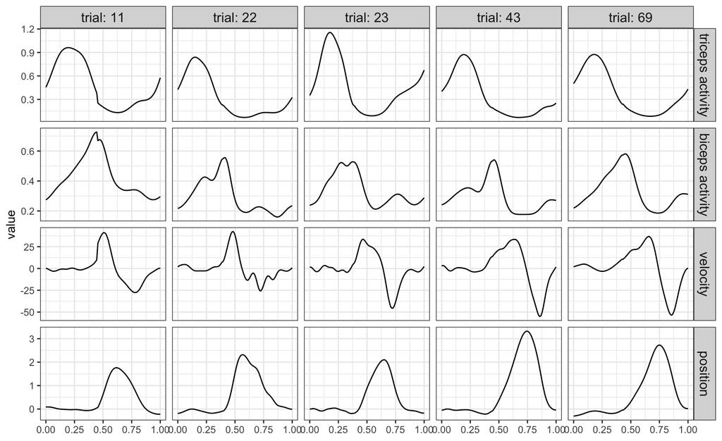

```r
set.seed(32543)
steps = sample(unique(reseg$trial), 5)
reseg %>%
  filter(trial %in% steps) %>%
  pivot_longer(value:tricep,
               names_to = "var",
               values_to = "value") %>%
  mutate(var =  factor(var, levels = c("tricep", "bicep",
                                       "v_up", "value"),
                       labels = c("triceps activity",
                                  "biceps activity",
                                  "velocity",
                                  "position"))) %>%
  ggplot(aes(time, value)) +
  geom_line() +
  facet_grid(var~trial, scales = "free_y",
             labeller = labeller(var = label_value,
                                 trial = label_both)) +
  theme(strip.text = element_text(size = 12),
        #strip.text = element_blank(1),
        axis.title.x = element_blank()) #
```

```r
df = reseg %>%
  mutate(trial = factor(trial)) %>%
  pivot_longer(value:tricep, names_to = "var", values_to = "value") %>%
  mutate(var =  factor(var, levels = c("tricep", "bicep", "v_up", "value"),
                       labels = c("triceps activity",
                                  "biceps activity", "velocity",
                                  "position")))
```

### Figure 5

This produces Figure 5 in the manuscript, and saves it to the `output` folder as `fig_wald_boot-1.png`. The Figure is created by modifying a figure with flode coefficient functions and 95% confidence intervals called `flode_coefs_plot` that is created in the `202311_dataAnalysis_prediction.Rmd` file.

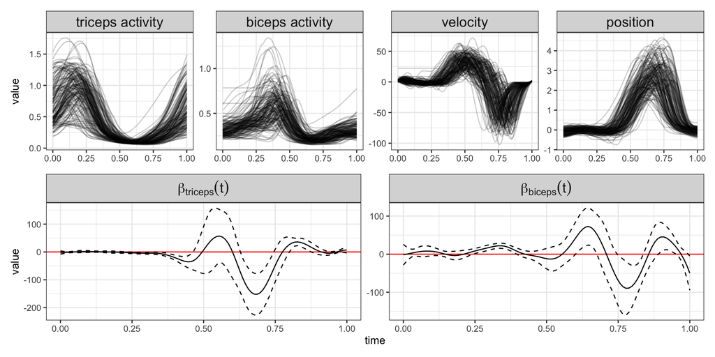

```r
load(file = here::here("output", "flode_coefs_plot.Rda"))


p2 = df %>%
  ggplot(aes(time, value, group = trial)) +
  geom_line(alpha = 0.2) +
  facet_wrap(~var, nrow = 1, scales = "free_y") +
  theme(strip.text = element_text(size = 14),
        axis.title.x = element_blank())


p2/flode_coefs_plot
```

# Supplement

Here we provide code to reproduce the supplemental figures that use the real data.

### Figure S5

Surfaces plots for flode and fhist

```r
make_surface_df = function(data, beta_num, model = "flode", D = 100){
  if(model == "flode"){
      surface = data$surface[[beta_num]]


  surface %>% as_tibble() %>%
    mutate(t = seq(0,1, length.out = D)) %>%
    gather(s, value, starts_with("s")) %>%
    arrange(t) %>%
    mutate(s = rep(seq(0,1, length.out = D), dim(data$surface[[1]])[1]),
           label = paste0("beta", beta_num - 1),
           model = model)
  }
  else if(model == "fhist"){
     ## calculate surface for fhist
    if(beta_num == 1){
      fhist_surface = coef(data, n1 = D, n2 = D)$smterms$"ff(x1,s)"$coef %>%
         select(s = x1.smat, t = x1.tmat, value = value) %>%
        as_tibble()

    }else if(beta_num == 2){
      fhist_surface = coef(data, n1 = D, n2 = D)$smterms$"ff(x2,s)"$coef %>%
         select(s = x2.smat, t = x2.tmat, value = value) %>%
        as_tibble()
    }

    fhist_surface = fhist_surface %>%
      select(t, s, value)

  ## interpolate surface to get on same grid as flode
  interp_obj = list(x = unique(fhist_surface$s), y = unique(fhist_surface$t),
                    z = matrix(fhist_surface$value, D, D, byrow = TRUE))

  tt = ss = seq(0, 1, length.out = D)
  loc_mat = list(x = ss, y = tt)
  fhist_surface = fields::interp.surface.grid(interp_obj, loc_mat)$z
  fhist_surface[D,] = fhist_surface[D-1,] # carry last value forward so not NA
  fhist_surface = fhist_surface * lower.tri(fhist_surface, diag = TRUE)# zero out upper triangle of the matrix

  colnames(fhist_surface) = paste0("s", ss)
  fhist_surface = fhist_surface %>%
    as_tibble() %>%
    mutate(t = tt) %>% select(t, everything()) %>%
    gather(s, value, starts_with("s")) %>%
    arrange(t) %>%
    mutate(s = rep(ss, D),
           label = paste0("beta", beta_num),
           model = model,
           value = ifelse(s <= t, value, NA))

  fhist_surface
  }
}

surface_df = map_dfr(2:3, make_surface_df, data = pUp_results)
surface_df_fhist = map_dfr(1:2, make_surface_df, data = pUp_fhist, model = "fhist")
```

```
## using seWithMean for  s(t.vec) .
## using seWithMean for  s(t.vec) .
```

```r
surface_df = bind_rows(surface_df, surface_df_fhist)
```

Saved as `appendix_surfaces-1` in the `output` folder.

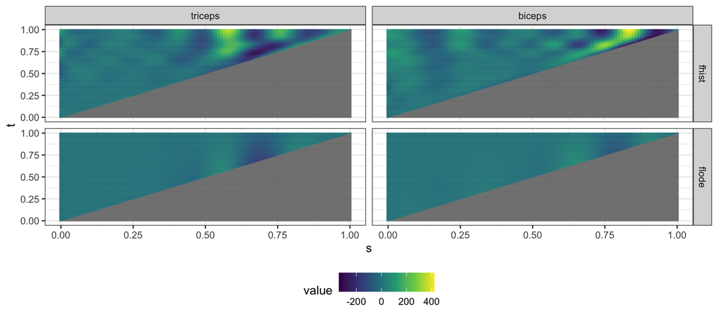

```r
surface_df %>%
  mutate(coef = factor(label, levels = c("beta2", "beta1"),
                       labels = c("triceps", "biceps")),
         value = ifelse(s>t, NA, value)) %>%
  ggplot(aes(s, t)) +
  geom_tile(aes(fill = value, col = value)) +
  scale_fill_viridis_c() +
  scale_colour_viridis_c() +
  facet_grid(model ~ coef) +
  theme(legend.position = "bottom")
```